# Assignment 5 - GitHub and the ticketmaster.com API

Marius Knipp (Student ID: 6290375)

2023-01-25

```r
library(jsonlite)
library(httr)
library(plyr)
library(tidyverse)
```

### Getting to know the API

6. Whithin the scope of this assignment, you do not have to request your own API key. Instead retrieve a valid key from the API Explorer. This API key enables you to perform the GET requests needed throughout this assignment. Even though this API key is not secret per se (it is publicly visible on the API Explorer website), please comply to the common secrecy practices discussed in the lecture and the tutorial: Treat the API key as a secret token. Your API key should neither appear in the code that you are submitting nor in your public GitHub repository.

```r
source('ticketmaster_key.R')
```

### Interacting with the API - the basics

7. Perform a first `GET` request, that searches for event venues in Germany (`countryCode = "DE"`). Extract the content from the response object and inspect the resulting list. Describe what you can see.

```r
content <- GET('https://app.ticketmaster.com/discovery/v2/venues.json?',
               query = list(apikey = ticketmaster_key,
                            locale = '*',
                            countryCode = 'DE')) %>% content()

content$page
```

```
## $size
## [1] 20
##
## $totalElements
## [1] 12932
##
## $totalPages
## [1] 647
##
## $number
## [1] 0
```

```r
names(content[['_embedded']][['venues']][[1]])
```

```
##  [1] "name"           "type"           "id"             "test"
##  [5] "url"            "locale"         "images"         "postalCode"
##  [9] "timezone"       "city"           "country"        "address"
## [13] "location"       "markets"        "dmas"           "boxOfficeInfo"
## [17] "upcomingEvents" "ada"            "_links"
```

*Answer: The list contains 20 venues in Germany with various information about each venue (e.g. name, URL, city etc.). These 20 venues are only on the first page. In total, there are 647 pages with 20 venues each, adding up to 12932 venues in Germany.*

8. Extract the `name`, the `city`, the `postalCode` and `address`, as well as the `url` and the `longitude` and `latitude` of the venues to a data frame.

```r
venues <- content[['_embedded']][['venues']]

venues_list <- list()

for (venue in venues) {
  venues_holder <- list()
  venues_holder['name'] <- venue$name
  venues_holder['city'] <- venue$city$name
  venues_holder['postalCode'] <- venue$postalCode
  venues_holder['address'] <- venue$address$line1
  venues_holder['url'] <- venue$url
  venues_holder['longitude'] <- venue$location$longitude
  venues_holder['latitude'] <- venue$location$latitude

  venues_list[[length(venues_list) + 1]] <- venues_holder
}

# Create dataframe
venues_df <- ldply(venues_list, data.frame)
```

### Interacting with the API - advanced

9. Have a closer look at the list element named page. Did your `GET` request from exercise (7) return all event locations in Germany? Obviously not - there are of course much more venues in Germany than those contained in this list. Your `GET` request only yielded the first results page containing the first 20 out of several thousands of venues. Check the API documentation under the section Venue Search. How can you request the venues from the remaining results pages? Iterate over the results pages and perform `GET` requests for all venues in Germany. After each iteration, extract the seven variables `name`, `city`, `postalCode`, `address`, `url`, `longitude`, and `latitude`. Join the information in one large data frame. Print the first 10 rows and the shape of the resulting data frame.

```r
get_venues <- function(country){

  # Perform GET request to extract the number of total pages
  content <- GET('https://app.ticketmaster.com/discovery/v2/venues.json?',
                 query = list(apikey = ticketmaster_key,
                              locale = '*',
                              countryCode = country)) %>% content()
  n_pages <- as.numeric(content$page$totalPages) - 1

  # Empty list to store data
  venues_list <- list()

  # Iterate through pages
  for (page in 0:n_pages) {
    # Limitation of 5 requests per second
    Sys.sleep(.2)

    # Perform GET request of the page in a while statement,
    # because sometimes an error occurs, when performing the GET request
    venues <- NULL
    while (is.null(venues)) {
      content <- GET('https://app.ticketmaster.com/discovery/v2/venues.json?',
                     query = list(apikey = ticketmaster_key,
                                  locale = '*',
                                  countryCode = country,
                                  page = page)) %>% content()

      venues <- content[['_embedded']][['venues']]
    }

    # Iterate through venues on the page
    for (venue in venues) {
      # Extract the information and store it in a list
      venues_holder <- list()
      venues_holder['name'] <- venue$name
      venues_holder['city'] <- venue$city$name
      venues_holder['postalCode'] <- venue$postalCode
      venues_holder['address'] <- venue$address$line1

      if (is.null(venues_holder['address'])) {
        venues_holder['address'] <- venue$address$line2
      }

      venues_holder['url'] <- venue$url
      venues_holder['longitude'] <- venue$location$longitude
      venues_holder['latitude'] <- venue$location$latitude

      # Append to the venues_list
      venues_list[[length(venues_list) + 1]] <- venues_holder
    }
  }

  # Convert list of lists to a data frame
  venues_df <- ldply(venues_list, data.frame)
  return(venues_df)
}

venues_germany <- get_venues('DE')

head(venues_germany, 10)
```

```
##                        name         city postalCode               address
## 1        Grosse Freiheit 36      Hamburg      22767    Grosse Freiheit 36
## 2                 Gruenspan      Hamburg      22767    Grosse Freiheit 58
## 3         Huxleys Neue Welt       Berlin      10967  Hasenheide 107 – 113
## 4           Zentrum am Park Emmelshausen      56281 Rhein-Mosel-Straße 45
## 5  Stadthalle (Theatersaal)      Mülheim      45479 Theodor-Heuss-Platz 1
## 6             Schlossgarten     Bruchsal      76646      Schloss Bruchsal
## 7                Stadthalle   Hockenheim      68766       Rathausstraße 3
## 8                       FZW     Dortmund      44263       Ritterstraße 20
## 9               Arena Trier        Trier      54292    Fort-Worth-Platz 1
## 10            Eissporthalle    Memmingen      87700   Hühnerbergstraße 19
##                                                                                         url
## 1                                                   http://www.ticketmaster.de/venue/287636
## 2                                                   http://www.ticketmaster.de/venue/287155
## 3                                                   http://www.ticketmaster.de/venue/286842
```

[output cut: 18 more lines]

```r
dim(venues_germany)
```

```
## [1] 12932     7
```

### Visualizing the extracted data

10. Below, you can find code that produces a map of Germany. Add points to the map indicating the locations of the event venues across Germany.
11. You will find that some coordinates lie way beyond the German borders and can be assumed to be faulty. Set coordinate values to `NA` where the value of `longitude` is outside the range (`5.866, 15.042`) or where the value of `latitude` is outside the range (`47.270, 55.059`).

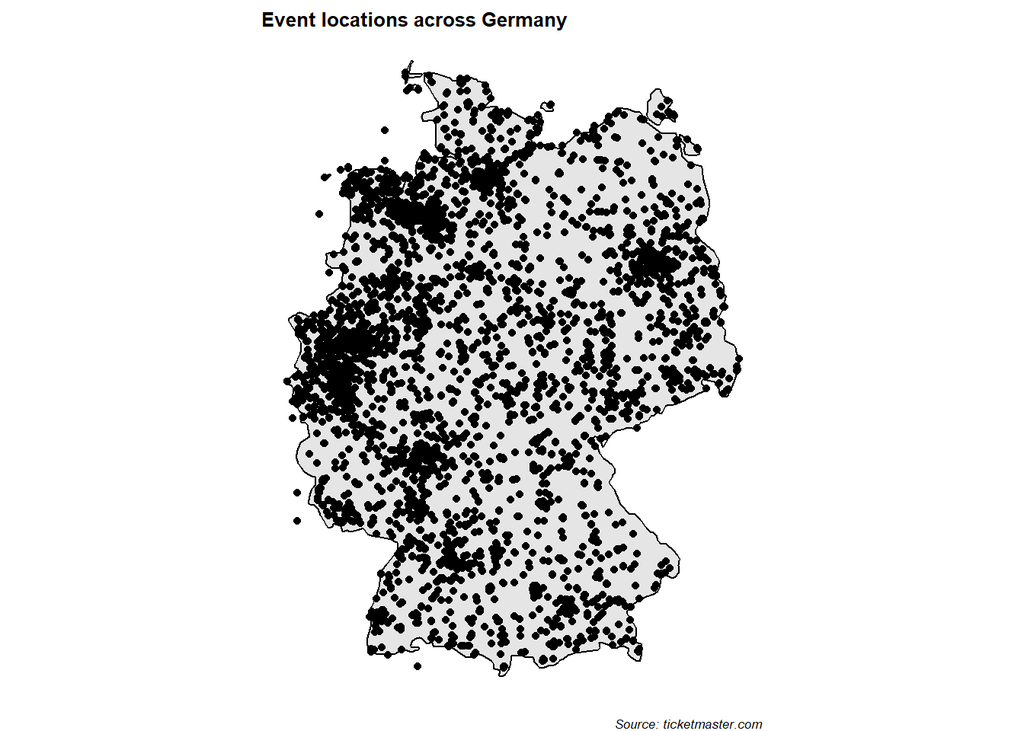

```r
plot_venues <- function(venues, country, lo_min, lo_max, lat_min, lat_max){

  # Change data type of 'longitude' and 'latitude' to numeric
  venues$longitude <- as.numeric(venues$longitude)
  venues$latitude <- as.numeric(venues$latitude)

  # Set coordinates outside the range to NaN
  venues$longitude[
    venues$longitude < lo_min | venues$longitude > lo_max] <- NA

  venues$latitude[
    venues$latitude < lat_min | venues$latitude > lat_max] <- NA

  # Plot the map with venues
  x = venues$longitude
  y = venues$latitude

  ggplot(venues, aes(x, y)) +
    borders("world", country, colour = "black", fill = "grey90") +
    theme_void() +
    coord_quickmap() +
    labs(title = paste('Event locations across', country),
         caption = "Source: ticketmaster.com") +
    theme(title = element_text(size = 8, face = 'bold'),
          plot.caption = element_text(face = "italic")) +
    geom_point()

}

# Extreme points of Germany
lo_min <- 5.866
lo_max <- 15.042
lat_min <- 47.270
lat_max <- 55.059

plot_venues(venues_germany, 'Germany', lo_min, lo_max, lat_min, lat_max)
```

### Event locations in other countries

12. Repeat exercises (9)–(11) for another European country of your choice. (Hint: Clean code pays off! If you have coded the exercises efficiently, only very few adaptions need to be made.)

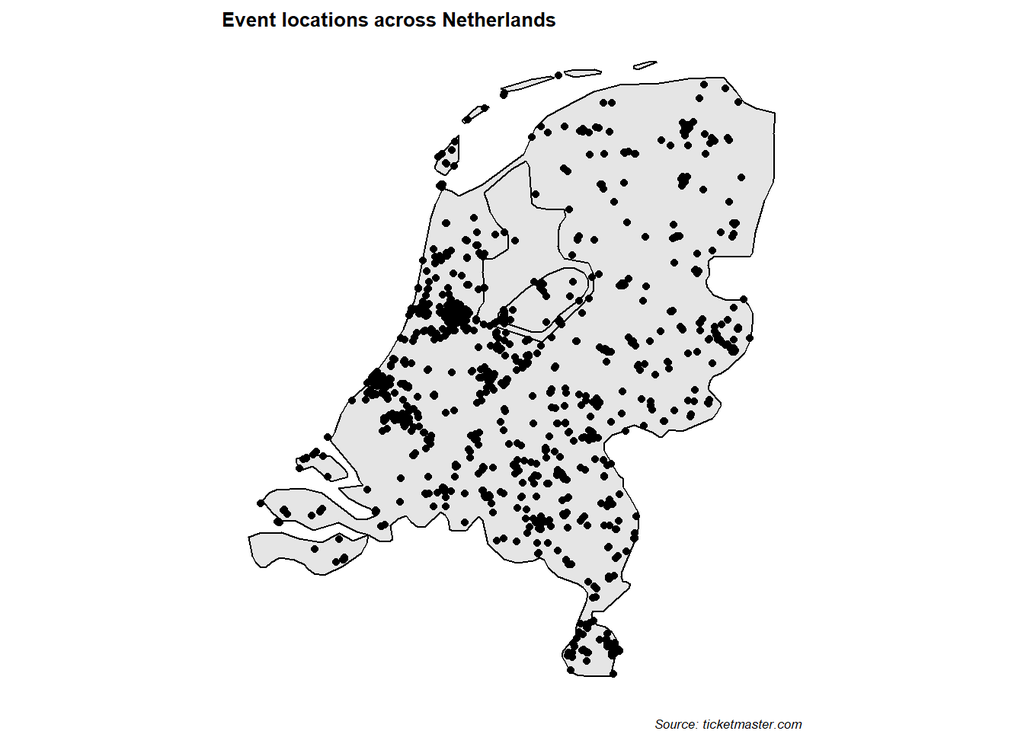

```r
venues_netherlands <- get_venues('NL')

# Extreme points of the Netherlands
lo_min <- 3.358
lo_max <- 7.228
lat_min <- 50.75
lat_max <- 53.555

plot_venues(venues_netherlands, 'Netherlands', lo_min, lo_max, lat_min, lat_max)
```